# 9 Public vs. private utility

The economic impact of bottom trawling extends beyond private financial returns, incorporating both public benefits and societal costs. While the industry is often evaluated based on profitability, a more comprehensive assessment considers its broader contributions to society and its environmental footprint.

From a private utility perspective, the fishery’s value lies in profits, which fluctuate with market conditions, operating costs, and regulations. In contrast, its public utility is more complex, balancing positive contributions, such as employment and food security, against negative externalities, including bycatch (not assessed here), discards, and CO₂ emissions. While the fishery supports jobs and provides protein, it also depletes marine resources and contributes to climate change through both fuel combustion and sediment disturbance, which releases stored carbon into the ocean.

On average, private utility was negative (-12,000 EUR per year, SD: 118,000 EUR), indicating that fishing costs generally exceeded revenue despite year-to-year variability (Figure 9.1). High energy expenses, depreciation, and crew wages were the primary cost drivers. Even as fishing effort declined in recent years, fuel and repair costs remained high, sustaining negative net profits.

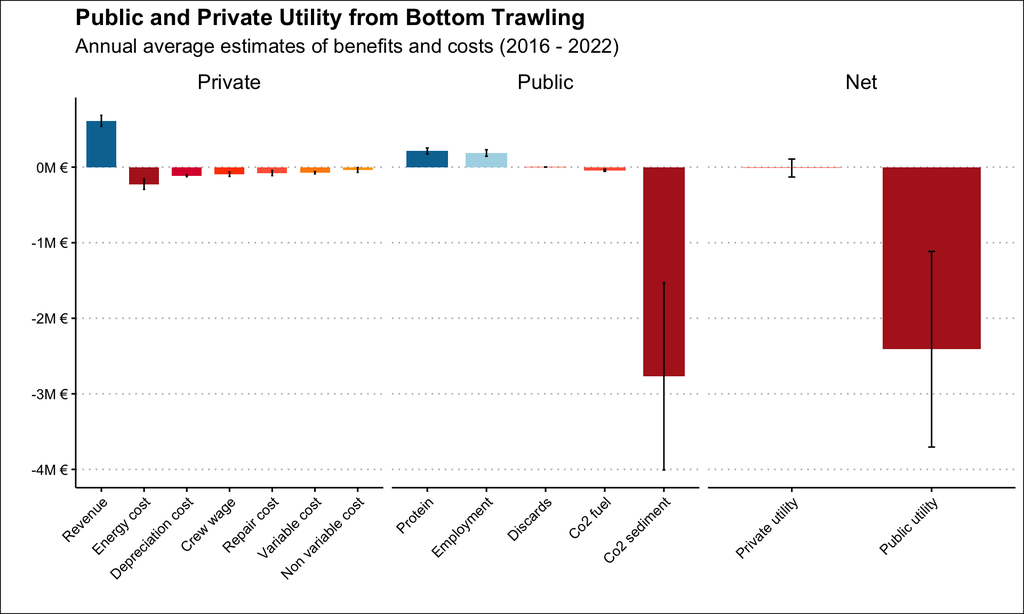

Figure 9.1: Public and Private Utility from Bottom Trawling

Using a conservative social cost of carbon (50 EUR per ton of CO₂), emissions from fuel combustion alone imposed an average annual cost of 41,600 EUR (SD: 14,000 EUR). However, the most significant climate impact came from sediment disturbance, generating an estimated annual carbon cost of 2.7 million EUR (SD: 1.2 million EUR) (Figure 9.1). This staggering figure underscores the hidden environmental burden of bottom trawling, reinforcing the need to account for both private profitability and the broader social and ecological costs of this fishing practice.